# Proyecto final

### Definimos taxa a filtrar

```r
filterPhyla = c("Aquificae", "Caldiserica","Candidatus_Acetothermia", "Candidatus_Aminicenantes", "Candidatus_Atribacteria", "Candidatus_Berkelbacteria", "Candidatus_Cloacimonetes", "Candidatus_Colwellbacteria", "Candidatus_Daviesbacteria", "Candidatus_Falkowbacteria", "Candidatus_Firestonebacteria","Candidatus_Gracilibacteria","Candidatus_Hydrogenedentes","Candidatus_Jorgensenbacteria", "Candidatus_Kerfeldbacteria","Candidatus_Komeilibacteria", "Candidatus_Kryptonia","Candidatus_Lindowbacteria","Candidatus_Lloydbacteria","Candidatus_Marinimicrobia",
                "Candidatus_Nomurabacteria","Candidatus_Parcubacteria","Candidatus_Portnoybacteria","Candidatus_Shapirobacteria","Candidatus_Vogelbacteria", "Candidatus_Woesebacteria", "Candidatus_Yonathbacteria", "Chlorobi", "Crenarchaeota",NA)
```

Procedemos a filtrar

```r
(psd1 = subset_taxa(ar, !Phylum %in% filterPhyla))
```

```
## phyloseq-class experiment-level object
## otu_table()   OTU Table:         [ 1945 taxa and 47 samples ]
## sample_data() Sample Data:       [ 47 samples by 54 sample variables ]
## tax_table()   Taxonomy Table:    [ 1945 taxa by 7 taxonomic ranks ]
```

```r
#Se realiza un subset de los datos presentes en el objeto phyloseq, esto mediante la indicación de que excluya aquellos Phylum que estén presentes en el vector de los phylum que poseen menos de cuatro lecturas o que están registrados con NA.
```

Observamos que nuestra OTU table se redujo de 2018 taxas a 1945, distribuídas en 47 muestras.

#### Seguimos filtrando…

Además del filtrado que acabamos de realizar, existen otros tipos de filtrado que tienen que ver con la media de read counts por taxa, con la distribución de éstas, y con filtrar muestras bajo un número mínimo de reads.

```r
# Filtramos taxa de acuerdo a un umbral de número medio de _read counts_, en este caso 1e-5

psd2 <- filter_taxa(psd1, function(x) mean(x) > 1e-5, TRUE)
psd3 <- filter_taxa(psd2, function(x) sum(x > 2) > (0.1*length(x)), TRUE)
# Y finalmente filtrar muestras con menos de 1000 reads
psd4 = prune_samples(sample_sums(psd3) > 1000, psd3)
psd4
```

```
## phyloseq-class experiment-level object
## otu_table()   OTU Table:         [ 528 taxa and 46 samples ]
## sample_data() Sample Data:       [ 46 samples by 54 sample variables ]
## tax_table()   Taxonomy Table:    [ 528 taxa by 7 taxonomic ranks ]
```

Otra forma de filtrar taxa de baja prevalencia es estableciendo un umbral y luego visualizar el efecto de manera gráfica.

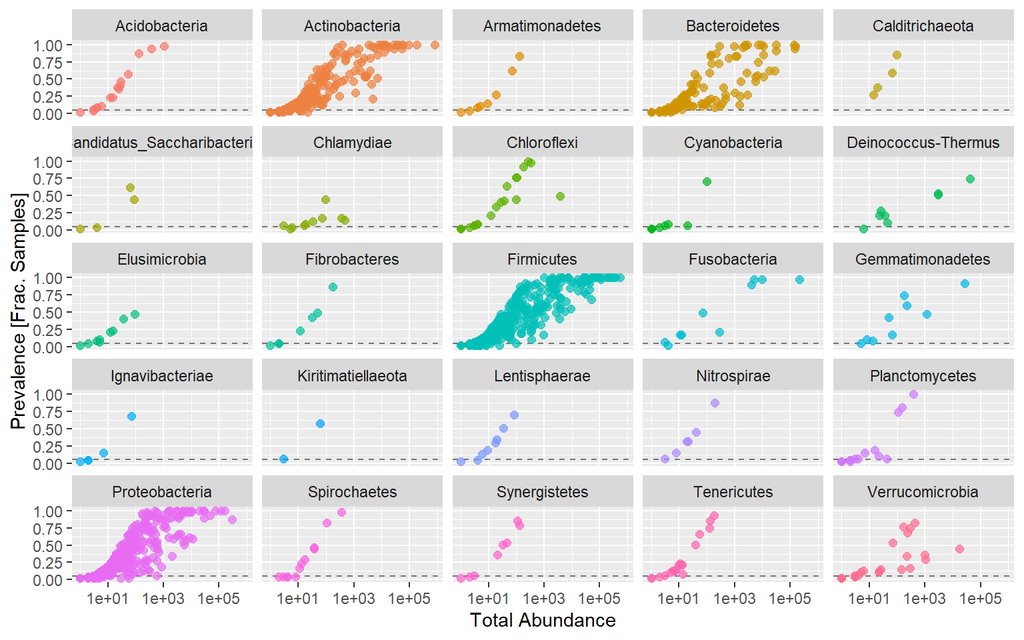

```r
prevdf1 <- subset(prevdf, Phylum %in% get_taxa_unique(psd4, "Phylum"))
ggplot(prevdf1, aes(TotalAbundance, Prevalence / nsamples(analyses_ps),color=Phylum)) +
  # Agregamos una línea para nuestro umbral
  geom_hline(yintercept = 0.05, alpha = 0.5, linetype = 2) +  geom_point(size = 2, alpha = 0.7) +
  scale_x_log10() +  xlab("Total Abundance") + ylab("Prevalence [Frac. Samples]") +
  facet_wrap(~Phylum) + theme(legend.position="none")+ geom_tile()
```

```r
(prevalenceThreshold = 0.05 * nsamples(psd4))
```

```
## [1] 2.3
```

## Filtrado por prevalencia, usando `prune_taxa()`

Aquí se filtra mediante prevalencia del cada taxa, para filtrarlo por el humbral de prevalencia que se estableció previamente.

```r
keepTaxa = rownames(prevdf1)[(prevdf1$Prevalence >= prevalenceThreshold)]
(psd5 = prune_taxa(keepTaxa, psd4))
```

```
## phyloseq-class experiment-level object
## otu_table()   OTU Table:         [ 528 taxa and 46 samples ]
## sample_data() Sample Data:       [ 46 samples by 54 sample variables ]
## tax_table()   Taxonomy Table:    [ 528 taxa by 7 taxonomic ranks ]
```

## Conclusiones

Nuestro proyecto partió del uso de datos de acceso libre para su posterior manipulación y análisis. No se pudieron rechazar ni comprobar las hipótesis debido a problemas relaccionados con el acceso a las variables dentro del objeto phyloseq y la ausencia de variables estratificadas en el mismo.

Las autoras esperan retroalimentación sobre el proyecto para su complementación y mejora, así como para brindar soluciones a este problema de manipulación y manejo de datos.

## Referencias bibliográficas

- Cortes, A., Peachey, L., Scotti, R., Jenkins, T. P., & Cantacessi, C. (2019). Helminth-microbiota cross-talk–A journey through the vertebrate digestive system. Molecular and Biochemical Parasitology, 233, 111222.
- EMBL-EBI | MGnify. Submit, analyse, discover and compare microbiome data. Study MGYS00003433. Helminth infections and gut microbiota a feline perspective. https://www.ebi.ac.uk/metagenomics/studies/MGYS00003433#overview
- Duarte, A. M., Jenkins, T. P., Latrofa, M. S., Giannelli, A., Papadopoulos, E., de Carvalho, L. M., … & Cantacessi, C. (2016). Helminth infections and gut microbiota–a feline perspective. Parasites & vectors, 9(1), 1-9.